# Using the tidyverse

[Download Tidyverse Tutorial Files](https://davidmartinconsulting.github.io/Compendium/Using_the_Tidyverse.zip)

# Tidyverse Overview

The `tidyverse` is a family of packages that share a similar grammar, syntax, and data structure. This similarity in programming style allows for an easy transition from learning one package to the next and from utilizing many packages to accomplish complicated tasks.

The `tidyverse` is built to help you accomplish all tasks within the data analysis pipeline ranging from data collection and cleaning all the way to data visualization and analysis.

This tutorial will describe the various packages that are included in the `tidyverse` and will give some simple examples of how to use the key packages.

# Packages Included in the Tidyverse

The following list is not every package that is downloaded when you install the `tidyverse`, but these are some of the main packages that are highly useful in everyday data analysis tasks:

- `readr` - The `readr` package allows you to read in data that are coming from typical data formats, such as fixed width data and csv files.
- `dplyr` - The `dplyr` package supplies a series of functions to aid in data manipulation and cleaning.
- `ggplot2` - The `ggplot2` package provides a “Grammar of Graphics” that allows you to create highly customizable visualizations layer by layer.
- `tidyr` - The `tidyr` package provides a series of functions to “tidy” your dataset and create a clean, easy to analyze/visualize dataset.
- `purrr` - The `purrr` package provides a consistent syntax that allows you to programmatically work with your data in a way that can save you time and create more efficient, easy to debug code.

## Installing the Tidyverse

To get started with the `tidyverse`, you need to run the `install.packages` function to download the `tidyverse` from the CRAN.

```r
install.packages("tidyverse")
```

You then need to load the packages so that you can use the associated functions.

```r
library(tidyverse)
```

Note: After loading the library, you might get warnings that you have conflicts. These occur when a function of the same name exists in two different packages. To ensure you are using the function you mean to, you can use the `package_name::function_name` syntax.

```r
dplyr::filter(varA > 50)
```

## `readr`

As mentioned earlier, the `readr` package provides the functionality to read data in from common data files. The main functions that I will discuss in this tutorial, are the `read_csv()` and `write_csv()` functions. These functions help you to read in and write out files to and from csv files. They behave quite similar to the `read_delim`, `read_fwf`, etc. functions. Below, we are going to read in data from the National Health and Nutrition Examination Survey and save it as an object.

```r
nh <- read_csv("https://davidmartinconsulting.github.io/Compendium/nhanes.csv")
```

The main input that is necessary for the `read_csv` function is the location of the file that you want to use.

For the `write_csv` function, you need to supply the object that you would like to export and the name and location of the new file you want to create.

```r
write_csv(nh, "nhanes.csv")
```

One final note for the `readr` package is that when using the `read_` functions, you will import the dataset as a tibble instead of a dataframe.

```r
class(nh)
```

```
## [1] "spec_tbl_df" "tbl_df"      "tbl"         "data.frame"
```

Tibbles are similar to dataframes, however, they have some additional aesthetic improvements and they can often convert columns to different data types than you would expect from a dataframe.

## `dplyr` functions

`dplyr` is a package in R that allows you to work with and manipulate your data. It allows you to focus in on the variables (columns) of interest and the observations (rows) of interest.

### Using The Pipe

The pipe is an operator in R that allows you to chain together functions in `dplyr`. In the past, to use multiple functions you would have to nest your functions inside of each other, but using the pipe allows you to chain the functions together in a readable/reproducible format. The pipe character is `%>%` and essentially means “then” You can create the character using `CTRL+SHIFT+M` or `CMD+SHIFT+M`. The pipe essentially takes whatever is before the pipe as input for whatever is after the pipe.

```r
# Normal way to view your dataset
View(nh)

# Using the pipe, the nh dataframe is passed on to the View function
nh %>%
  View()

# The head function looks at the top of the dataframe
head(nh)
```

```
## # A tibble: 6 × 76
##      ID Surve…¹ Gender   Age AgeDe…² AgeMo…³ Race1 Race3 Educa…⁴ Marit…⁵ HHInc…⁶
##   <dbl> <chr>   <chr>  <dbl> <chr>     <dbl> <chr> <chr> <chr>   <chr>   <chr>
## 1 51624 2009_10 male      34 30-39       409 White <NA>  High S… Married 25000-…
## 2 51624 2009_10 male      34 30-39       409 White <NA>  High S… Married 25000-…
## 3 51624 2009_10 male      34 30-39       409 White <NA>  High S… Married 25000-…
## 4 51625 2009_10 male       4 0-9          49 Other <NA>  <NA>    <NA>    20000-…
## 5 51630 2009_10 female    49 40-49       596 White <NA>  Some C… LivePa… 35000-…
## 6 51638 2009_10 male       9 0-9         115 White <NA>  <NA>    <NA>    75000-…
## # … with 65 more variables: HHIncomeMid <dbl>, Poverty <dbl>, HomeRooms <dbl>,
## #   HomeOwn <chr>, Work <chr>, Weight <dbl>, Length <dbl>, HeadCirc <dbl>,
## #   Height <dbl>, BMI <dbl>, BMICatUnder20yrs <chr>, BMI_WHO <chr>,
## #   Pulse <dbl>, BPSysAve <dbl>, BPDiaAve <dbl>, BPSys1 <dbl>, BPDia1 <dbl>,
## #   BPSys2 <dbl>, BPDia2 <dbl>, BPSys3 <dbl>, BPDia3 <dbl>, Testosterone <dbl>,
## #   DirectChol <dbl>, TotChol <dbl>, UrineVol1 <dbl>, UrineFlow1 <dbl>,
## #   UrineVol2 <dbl>, UrineFlow2 <dbl>, Diabetes <chr>, DiabetesAge <dbl>, …
```

```r
# When you have a function with multiple arguments, the first argument will
# be taken from whatever is before the pipe operator.
head(nh, 3)
```

```
## # A tibble: 3 × 76
##      ID Surve…¹ Gender   Age AgeDe…² AgeMo…³ Race1 Race3 Educa…⁴ Marit…⁵ HHInc…⁶
##   <dbl> <chr>   <chr>  <dbl> <chr>     <dbl> <chr> <chr> <chr>   <chr>   <chr>
## 1 51624 2009_10 male      34 30-39       409 White <NA>  High S… Married 25000-…
## 2 51624 2009_10 male      34 30-39       409 White <NA>  High S… Married 25000-…
## 3 51624 2009_10 male      34 30-39       409 White <NA>  High S… Married 25000-…
## # … with 65 more variables: HHIncomeMid <dbl>, Poverty <dbl>, HomeRooms <dbl>,
## #   HomeOwn <chr>, Work <chr>, Weight <dbl>, Length <dbl>, HeadCirc <dbl>,
## #   Height <dbl>, BMI <dbl>, BMICatUnder20yrs <chr>, BMI_WHO <chr>,
## #   Pulse <dbl>, BPSysAve <dbl>, BPDiaAve <dbl>, BPSys1 <dbl>, BPDia1 <dbl>,
## #   BPSys2 <dbl>, BPDia2 <dbl>, BPSys3 <dbl>, BPDia3 <dbl>, Testosterone <dbl>,
## #   DirectChol <dbl>, TotChol <dbl>, UrineVol1 <dbl>, UrineFlow1 <dbl>,
## #   UrineVol2 <dbl>, UrineFlow2 <dbl>, Diabetes <chr>, DiabetesAge <dbl>, …
```

```r
nh %>%
  head(3)
```

```
## # A tibble: 3 × 76
##      ID Surve…¹ Gender   Age AgeDe…² AgeMo…³ Race1 Race3 Educa…⁴ Marit…⁵ HHInc…⁶
##   <dbl> <chr>   <chr>  <dbl> <chr>     <dbl> <chr> <chr> <chr>   <chr>   <chr>
## 1 51624 2009_10 male      34 30-39       409 White <NA>  High S… Married 25000-…
## 2 51624 2009_10 male      34 30-39       409 White <NA>  High S… Married 25000-…
## 3 51624 2009_10 male      34 30-39       409 White <NA>  High S… Married 25000-…
## # … with 65 more variables: HHIncomeMid <dbl>, Poverty <dbl>, HomeRooms <dbl>,
## #   HomeOwn <chr>, Work <chr>, Weight <dbl>, Length <dbl>, HeadCirc <dbl>,
## #   Height <dbl>, BMI <dbl>, BMICatUnder20yrs <chr>, BMI_WHO <chr>,
## #   Pulse <dbl>, BPSysAve <dbl>, BPDiaAve <dbl>, BPSys1 <dbl>, BPDia1 <dbl>,
## #   BPSys2 <dbl>, BPDia2 <dbl>, BPSys3 <dbl>, BPDia3 <dbl>, Testosterone <dbl>,
## #   DirectChol <dbl>, TotChol <dbl>, UrineVol1 <dbl>, UrineFlow1 <dbl>,
## #   UrineVol2 <dbl>, UrineFlow2 <dbl>, Diabetes <chr>, DiabetesAge <dbl>, …
```

```r
nh %>%
  head(5) %>%
  tail(1)
```

```
## # A tibble: 1 × 76
##      ID Surve…¹ Gender   Age AgeDe…² AgeMo…³ Race1 Race3 Educa…⁴ Marit…⁵ HHInc…⁶
##   <dbl> <chr>   <chr>  <dbl> <chr>     <dbl> <chr> <chr> <chr>   <chr>   <chr>
## 1 51630 2009_10 female    49 40-49       596 White <NA>  Some C… LivePa… 35000-…
## # … with 65 more variables: HHIncomeMid <dbl>, Poverty <dbl>, HomeRooms <dbl>,
## #   HomeOwn <chr>, Work <chr>, Weight <dbl>, Length <dbl>, HeadCirc <dbl>,
## #   Height <dbl>, BMI <dbl>, BMICatUnder20yrs <chr>, BMI_WHO <chr>,
## #   Pulse <dbl>, BPSysAve <dbl>, BPDiaAve <dbl>, BPSys1 <dbl>, BPDia1 <dbl>,
## #   BPSys2 <dbl>, BPDia2 <dbl>, BPSys3 <dbl>, BPDia3 <dbl>, Testosterone <dbl>,
## #   DirectChol <dbl>, TotChol <dbl>, UrineVol1 <dbl>, UrineFlow1 <dbl>,
## #   UrineVol2 <dbl>, UrineFlow2 <dbl>, Diabetes <chr>, DiabetesAge <dbl>, …
```

```r
# The pipe is useful for cases like this, where you have three nested functions
head(tail(head(nh, 36), 15), 3)
```

```
## # A tibble: 3 × 76
##      ID Surve…¹ Gender   Age AgeDe…² AgeMo…³ Race1 Race3 Educa…⁴ Marit…⁵ HHInc…⁶
##   <dbl> <chr>   <chr>  <dbl> <chr>     <dbl> <chr> <chr> <chr>   <chr>   <chr>
## 1 51685 2009_10 female    56 50-59       677 White <NA>  Colleg… Married 75000-…
## 2 51691 2009_10 female    57 50-59       694 White <NA>  High S… Married <NA>
## 3 51692 2009_10 male      54 50-59       655 Hisp… <NA>  Colleg… Divorc… 55000-…
## # … with 65 more variables: HHIncomeMid <dbl>, Poverty <dbl>, HomeRooms <dbl>,
## #   HomeOwn <chr>, Work <chr>, Weight <dbl>, Length <dbl>, HeadCirc <dbl>,
## #   Height <dbl>, BMI <dbl>, BMICatUnder20yrs <chr>, BMI_WHO <chr>,
## #   Pulse <dbl>, BPSysAve <dbl>, BPDiaAve <dbl>, BPSys1 <dbl>, BPDia1 <dbl>,
## #   BPSys2 <dbl>, BPDia2 <dbl>, BPSys3 <dbl>, BPDia3 <dbl>, Testosterone <dbl>,
## #   DirectChol <dbl>, TotChol <dbl>, UrineVol1 <dbl>, UrineFlow1 <dbl>,
## #   UrineVol2 <dbl>, UrineFlow2 <dbl>, Diabetes <chr>, DiabetesAge <dbl>, …
```

```r
nh %>%
  head(36) %>%
  tail(15) %>%
  head(3)
```

```
## # A tibble: 3 × 76
##      ID Surve…¹ Gender   Age AgeDe…² AgeMo…³ Race1 Race3 Educa…⁴ Marit…⁵ HHInc…⁶
##   <dbl> <chr>   <chr>  <dbl> <chr>     <dbl> <chr> <chr> <chr>   <chr>   <chr>
## 1 51685 2009_10 female    56 50-59       677 White <NA>  Colleg… Married 75000-…
## 2 51691 2009_10 female    57 50-59       694 White <NA>  High S… Married <NA>
## 3 51692 2009_10 male      54 50-59       655 Hisp… <NA>  Colleg… Divorc… 55000-…
## # … with 65 more variables: HHIncomeMid <dbl>, Poverty <dbl>, HomeRooms <dbl>,
## #   HomeOwn <chr>, Work <chr>, Weight <dbl>, Length <dbl>, HeadCirc <dbl>,
## #   Height <dbl>, BMI <dbl>, BMICatUnder20yrs <chr>, BMI_WHO <chr>,
## #   Pulse <dbl>, BPSysAve <dbl>, BPDiaAve <dbl>, BPSys1 <dbl>, BPDia1 <dbl>,
## #   BPSys2 <dbl>, BPDia2 <dbl>, BPSys3 <dbl>, BPDia3 <dbl>, Testosterone <dbl>,
## #   DirectChol <dbl>, TotChol <dbl>, UrineVol1 <dbl>, UrineFlow1 <dbl>,
## #   UrineVol2 <dbl>, UrineFlow2 <dbl>, Diabetes <chr>, DiabetesAge <dbl>, …
```

### `distinct`/`count`

The distinct function will provide for you the distinct values of a column, while count provides you with both the distinct values of a column and then number of times each value shows up. The following example investigates the different Education Levels (`Education`) in the `nh` dataset:

```r
names(nh)
```

```
##  [1] "ID"               "SurveyYr"         "Gender"           "Age"
##  [5] "AgeDecade"        "AgeMonths"        "Race1"            "Race3"
##  [9] "Education"        "MaritalStatus"    "HHIncome"         "HHIncomeMid"
## [13] "Poverty"          "HomeRooms"        "HomeOwn"          "Work"
## [17] "Weight"           "Length"           "HeadCirc"         "Height"
## [21] "BMI"              "BMICatUnder20yrs" "BMI_WHO"          "Pulse"
## [25] "BPSysAve"         "BPDiaAve"         "BPSys1"           "BPDia1"
## [29] "BPSys2"           "BPDia2"           "BPSys3"           "BPDia3"
## [33] "Testosterone"     "DirectChol"       "TotChol"          "UrineVol1"
## [37] "UrineFlow1"       "UrineVol2"        "UrineFlow2"       "Diabetes"
## [41] "DiabetesAge"      "HealthGen"        "DaysPhysHlthBad"  "DaysMentHlthBad"
## [45] "LittleInterest"   "Depressed"        "nPregnancies"     "nBabies"
## [49] "Age1stBaby"       "SleepHrsNight"    "SleepTrouble"     "PhysActive"
## [53] "PhysActiveDays"   "TVHrsDay"         "CompHrsDay"       "TVHrsDayChild"
## [57] "CompHrsDayChild"  "Alcohol12PlusYr"  "AlcoholDay"       "AlcoholYear"
## [61] "SmokeNow"         "Smoke100"         "Smoke100n"        "SmokeAge"
## [65] "Marijuana"        "AgeFirstMarij"    "RegularMarij"     "AgeRegMarij"
## [69] "HardDrugs"        "SexEver"          "SexAge"           "SexNumPartnLife"
## [73] "SexNumPartYear"   "SameSex"          "SexOrientation"   "PregnantNow"
```

```r
nh %>%
  distinct(Education)
```

```
## # A tibble: 6 × 1
##   Education
##   <chr>
## 1 High School
## 2 <NA>
## 3 Some College
## 4 College Grad
## 5 9 - 11th Grade
## 6 8th Grade
```

```r
#Pipe into nrow() to get the number of distinct Education levels
# (other functions also exist to do something similar)
nh %>%
  distinct(Education) %>%
  nrow()
```

```
## [1] 6
```

```r
nh %>%
  count(Education)
```

```
## # A tibble: 6 × 2
##   Education          n
##   <chr>          <int>
## 1 8th Grade        451
## 2 9 - 11th Grade   888
## 3 College Grad    2098
## 4 High School     1517
## 5 Some College    2267
## 6 <NA>            2779
```

### `arrange`

The `arrange()` function does what it sounds like. It takes a data frame or tbl and arranges (or sorts) by column(s) of interest. The first argument is the data, and subsequent arguments are columns to sort on. Use the `desc()` function to arrange by descending.

```r
nh %>%
  count(Education) %>%
  arrange(n)
```

```
## # A tibble: 6 × 2
##   Education          n
##   <chr>          <int>
## 1 8th Grade        451
## 2 9 - 11th Grade   888
## 3 High School     1517
## 4 College Grad    2098
## 5 Some College    2267
## 6 <NA>            2779
```

```r
# Since the default is ascending order, we are not getting the results that are probably useful, so let's use the desc() function
nh %>%
  count(Education) %>%
  arrange(desc(n))
```

```
## # A tibble: 6 × 2
##   Education          n
##   <chr>          <int>
## 1 <NA>            2779
## 2 Some College    2267
## 3 College Grad    2098
## 4 High School     1517
## 5 9 - 11th Grade   888
## 6 8th Grade        451
```

### `filter`

If you want to filter **rows** of the data where some condition is true, use the `filter()` function.

1. The first argument is the dataset you want to filter, e.g. `filter(mydata, ...`.
2. The second argument is a condition you must satisfy, e.g. `filter(clean, variable == "levelA")`.
- `==`: Equal to
- `!=`: Not equal to
- `>`, `>=`: Greater than, greater than or equal to
- `<`, `<=`: Less than, less than or equal to

If you want to satisfy *all* of multiple conditions, you can use the “and” operator, `&`. The “or” operator `|` (the pipe character, usually shift-backslash) will return a subset that meet *any* of the conditions.

```r
#Keeps those patients younger than 30
nh %>%
  filter(Age < 30)
```

```
## # A tibble: 4,121 × 76
##       ID SurveyYr Gender   Age AgeDecade AgeMonths Race1 Race3 Education Marit…¹
##    <dbl> <chr>    <chr>  <dbl> <chr>         <dbl> <chr> <chr> <chr>     <chr>
##  1 51625 2009_10  male       4 0-9              49 Other <NA>  <NA>      <NA>
##  2 51638 2009_10  male       9 0-9             115 White <NA>  <NA>      <NA>
##  3 51646 2009_10  male       8 0-9             101 White <NA>  <NA>      <NA>
##  4 51659 2009_10  female    10 10-19           123 White <NA>  <NA>      <NA>
##  5 51671 2009_10  female     9 0-9             112 Black <NA>  <NA>      <NA>
##  6 51679 2009_10  male      16 10-19           194 Other <NA>  <NA>      <NA>
##  7 51695 2009_10  male       8 0-9             104 White <NA>  <NA>      <NA>
##  8 51710 2009_10  female    26 20-29           319 White <NA>  College … Married
##  9 51719 2009_10  male      17 10-19           211 White <NA>  <NA>      <NA>
## 10 51720 2009_10  male      12 10-19           152 Other <NA>  <NA>      <NA>
## # … with 4,111 more rows, 66 more variables: HHIncome <chr>, HHIncomeMid <dbl>,
## #   Poverty <dbl>, HomeRooms <dbl>, HomeOwn <chr>, Work <chr>, Weight <dbl>,
## #   Length <dbl>, HeadCirc <dbl>, Height <dbl>, BMI <dbl>,
## #   BMICatUnder20yrs <chr>, BMI_WHO <chr>, Pulse <dbl>, BPSysAve <dbl>,
## #   BPDiaAve <dbl>, BPSys1 <dbl>, BPDia1 <dbl>, BPSys2 <dbl>, BPDia2 <dbl>,
## #   BPSys3 <dbl>, BPDia3 <dbl>, Testosterone <dbl>, DirectChol <dbl>,
## #   TotChol <dbl>, UrineVol1 <dbl>, UrineFlow1 <dbl>, UrineVol2 <dbl>, …
```

```r
#Keeps those patients younger than 30 who are College Grad
nh %>%
  filter(Age < 30 & Education == "College Grad")
```

```
## # A tibble: 293 × 76
##       ID SurveyYr Gender   Age AgeDecade AgeMonths Race1 Race3 Education Marit…¹
##    <dbl> <chr>    <chr>  <dbl> <chr>         <dbl> <chr> <chr> <chr>     <chr>
##  1 51710 2009_10  female    26 20-29           319 White <NA>  College … Married
##  2 51764 2009_10  female    29 20-29           357 White <NA>  College … NeverM…
##  3 51764 2009_10  female    29 20-29           357 White <NA>  College … NeverM…
##  4 51764 2009_10  female    29 20-29           357 White <NA>  College … NeverM…
##  5 51781 2009_10  male      29 20-29           359 White <NA>  College … Married
##  6 51781 2009_10  male      29 20-29           359 White <NA>  College … Married
##  7 51781 2009_10  male      29 20-29           359 White <NA>  College … Married
##  8 51781 2009_10  male      29 20-29           359 White <NA>  College … Married
##  9 51801 2009_10  male      26 20-29           315 Other <NA>  College … NeverM…
## 10 51958 2009_10  male      29 20-29           353 Other <NA>  College … Married
## # … with 283 more rows, 66 more variables: HHIncome <chr>, HHIncomeMid <dbl>,
## #   Poverty <dbl>, HomeRooms <dbl>, HomeOwn <chr>, Work <chr>, Weight <dbl>,
## #   Length <dbl>, HeadCirc <dbl>, Height <dbl>, BMI <dbl>,
## #   BMICatUnder20yrs <chr>, BMI_WHO <chr>, Pulse <dbl>, BPSysAve <dbl>,
## #   BPDiaAve <dbl>, BPSys1 <dbl>, BPDia1 <dbl>, BPSys2 <dbl>, BPDia2 <dbl>,
## #   BPSys3 <dbl>, BPDia3 <dbl>, Testosterone <dbl>, DirectChol <dbl>,
## #   TotChol <dbl>, UrineVol1 <dbl>, UrineFlow1 <dbl>, UrineVol2 <dbl>, …
```

```r
# The filter function is helpful for dropping missing values
nh %>%
  filter(!is.na(Education)) # ! means "not", this essentially says "not missing"
```

```
## # A tibble: 7,221 × 76
##       ID SurveyYr Gender   Age AgeDecade AgeMonths Race1 Race3 Education Marit…¹
##    <dbl> <chr>    <chr>  <dbl> <chr>         <dbl> <chr> <chr> <chr>     <chr>
##  1 51624 2009_10  male      34 30-39           409 White <NA>  High Sch… Married
##  2 51624 2009_10  male      34 30-39           409 White <NA>  High Sch… Married
##  3 51624 2009_10  male      34 30-39           409 White <NA>  High Sch… Married
##  4 51630 2009_10  female    49 40-49           596 White <NA>  Some Col… LivePa…
##  5 51647 2009_10  female    45 40-49           541 White <NA>  College … Married
##  6 51647 2009_10  female    45 40-49           541 White <NA>  College … Married
##  7 51647 2009_10  female    45 40-49           541 White <NA>  College … Married
##  8 51654 2009_10  male      66 60-69           795 White <NA>  Some Col… Married
##  9 51656 2009_10  male      58 50-59           707 White <NA>  College … Divorc…
## 10 51657 2009_10  male      54 50-59           654 White <NA>  9 - 11th… Married
## # … with 7,211 more rows, 66 more variables: HHIncome <chr>, HHIncomeMid <dbl>,
## #   Poverty <dbl>, HomeRooms <dbl>, HomeOwn <chr>, Work <chr>, Weight <dbl>,
## #   Length <dbl>, HeadCirc <dbl>, Height <dbl>, BMI <dbl>,
## #   BMICatUnder20yrs <chr>, BMI_WHO <chr>, Pulse <dbl>, BPSysAve <dbl>,
## #   BPDiaAve <dbl>, BPSys1 <dbl>, BPDia1 <dbl>, BPSys2 <dbl>, BPDia2 <dbl>,
## #   BPSys3 <dbl>, BPDia3 <dbl>, Testosterone <dbl>, DirectChol <dbl>,
## #   TotChol <dbl>, UrineVol1 <dbl>, UrineFlow1 <dbl>, UrineVol2 <dbl>, …
```

```r
# drop_na works in a similar manner
nh %>%
  drop_na(Education)
```

```
## # A tibble: 7,221 × 76
##       ID SurveyYr Gender   Age AgeDecade AgeMonths Race1 Race3 Education Marit…¹
##    <dbl> <chr>    <chr>  <dbl> <chr>         <dbl> <chr> <chr> <chr>     <chr>
##  1 51624 2009_10  male      34 30-39           409 White <NA>  High Sch… Married
##  2 51624 2009_10  male      34 30-39           409 White <NA>  High Sch… Married
##  3 51624 2009_10  male      34 30-39           409 White <NA>  High Sch… Married
##  4 51630 2009_10  female    49 40-49           596 White <NA>  Some Col… LivePa…
##  5 51647 2009_10  female    45 40-49           541 White <NA>  College … Married
##  6 51647 2009_10  female    45 40-49           541 White <NA>  College … Married
##  7 51647 2009_10  female    45 40-49           541 White <NA>  College … Married
##  8 51654 2009_10  male      66 60-69           795 White <NA>  Some Col… Married
##  9 51656 2009_10  male      58 50-59           707 White <NA>  College … Divorc…
## 10 51657 2009_10  male      54 50-59           654 White <NA>  9 - 11th… Married
## # … with 7,211 more rows, 66 more variables: HHIncome <chr>, HHIncomeMid <dbl>,
## #   Poverty <dbl>, HomeRooms <dbl>, HomeOwn <chr>, Work <chr>, Weight <dbl>,
## #   Length <dbl>, HeadCirc <dbl>, Height <dbl>, BMI <dbl>,
## #   BMICatUnder20yrs <chr>, BMI_WHO <chr>, Pulse <dbl>, BPSysAve <dbl>,
## #   BPDiaAve <dbl>, BPSys1 <dbl>, BPDia1 <dbl>, BPSys2 <dbl>, BPDia2 <dbl>,
## #   BPSys3 <dbl>, BPDia3 <dbl>, Testosterone <dbl>, DirectChol <dbl>,
## #   TotChol <dbl>, UrineVol1 <dbl>, UrineFlow1 <dbl>, UrineVol2 <dbl>, …
```

```r
# You can also save the results of the filter function to create a more focused
# dataset
young_patients <- nh %>%
  filter(Age < 30)

young_patients %>% head(20)
```

```
## # A tibble: 20 × 76
##       ID SurveyYr Gender   Age AgeDecade AgeMonths Race1 Race3 Education Marit…¹
##    <dbl> <chr>    <chr>  <dbl> <chr>         <dbl> <chr> <chr> <chr>     <chr>
##  1 51625 2009_10  male       4 0-9              49 Other <NA>  <NA>      <NA>
##  2 51638 2009_10  male       9 0-9             115 White <NA>  <NA>      <NA>
##  3 51646 2009_10  male       8 0-9             101 White <NA>  <NA>      <NA>
##  4 51659 2009_10  female    10 10-19           123 White <NA>  <NA>      <NA>
##  5 51671 2009_10  female     9 0-9             112 Black <NA>  <NA>      <NA>
##  6 51679 2009_10  male      16 10-19           194 Other <NA>  <NA>      <NA>
##  7 51695 2009_10  male       8 0-9             104 White <NA>  <NA>      <NA>
##  8 51710 2009_10  female    26 20-29           319 White <NA>  College … Married
##  9 51719 2009_10  male      17 10-19           211 White <NA>  <NA>      <NA>
## 10 51720 2009_10  male      12 10-19           152 Other <NA>  <NA>      <NA>
## 11 51720 2009_10  male      12 10-19           152 Other <NA>  <NA>      <NA>
## 12 51722 2009_10  male      16 10-19           199 White <NA>  <NA>      <NA>
## 13 51722 2009_10  male      16 10-19           199 White <NA>  <NA>      <NA>
## 14 51722 2009_10  male      16 10-19           199 White <NA>  <NA>      <NA>
## 15 51722 2009_10  male      16 10-19           199 White <NA>  <NA>      <NA>
## 16 51723 2009_10  male      28 20-29           336 Black <NA>  Some Col… LivePa…
## 17 51731 2009_10  female    28 20-29           346 Black <NA>  High Sch… NeverM…
## 18 51734 2009_10  male      25 20-29           310 White <NA>  High Sch… Married
## 19 51741 2009_10  female    21 20-29           253 Black <NA>  Some Col… NeverM…
## 20 51741 2009_10  female    21 20-29           253 Black <NA>  Some Col… NeverM…
## # … with 66 more variables: HHIncome <chr>, HHIncomeMid <dbl>, Poverty <dbl>,
## #   HomeRooms <dbl>, HomeOwn <chr>, Work <chr>, Weight <dbl>, Length <dbl>,
## #   HeadCirc <dbl>, Height <dbl>, BMI <dbl>, BMICatUnder20yrs <chr>,
## #   BMI_WHO <chr>, Pulse <dbl>, BPSysAve <dbl>, BPDiaAve <dbl>, BPSys1 <dbl>,
## #   BPDia1 <dbl>, BPSys2 <dbl>, BPDia2 <dbl>, BPSys3 <dbl>, BPDia3 <dbl>,
## #   Testosterone <dbl>, DirectChol <dbl>, TotChol <dbl>, UrineVol1 <dbl>,
## #   UrineFlow1 <dbl>, UrineVol2 <dbl>, UrineFlow2 <dbl>, Diabetes <chr>, …
```

### `select`

Whereas the `filter()` function allows you to return only certain *rows* matching a condition, the `select()` function returns only certain *columns*. The first argument is the data, and subsequent arguments are the columns you want.

```r
# You can simply list the column names you want to keep
nh %>%
  select(ID)
```

```
## # A tibble: 10,000 × 1
##       ID
##    <dbl>
##  1 51624
##  2 51624
##  3 51624
##  4 51625
##  5 51630
##  6 51638
##  7 51646
##  8 51647
##  9 51647
## 10 51647
## # … with 9,990 more rows
```

```r
# Multiple columns can be separated by a comma
nh %>%
  select(ID, Gender, Age)
```

```
## # A tibble: 10,000 × 3
##       ID Gender   Age
##    <dbl> <chr>  <dbl>
##  1 51624 male      34
##  2 51624 male      34
##  3 51624 male      34
##  4 51625 male       4
##  5 51630 female    49
##  6 51638 male       9
##  7 51646 male       8
##  8 51647 female    45
##  9 51647 female    45
## 10 51647 female    45
## # … with 9,990 more rows
```

```r
# Or you can use the - sign to tell dplyr the columns you want to drop
nh %>%
  select(-ID, -Gender, -Age)
```

```
## # A tibble: 10,000 × 73
##    SurveyYr AgeDec…¹ AgeMo…² Race1 Race3 Educa…³ Marit…⁴ HHInc…⁵ HHInc…⁶ Poverty
##    <chr>    <chr>      <dbl> <chr> <chr> <chr>   <chr>   <chr>     <dbl>   <dbl>
##  1 2009_10  30-39        409 White <NA>  High S… Married 25000-…   30000    1.36
##  2 2009_10  30-39        409 White <NA>  High S… Married 25000-…   30000    1.36
##  3 2009_10  30-39        409 White <NA>  High S… Married 25000-…   30000    1.36
##  4 2009_10  0-9           49 Other <NA>  <NA>    <NA>    20000-…   22500    1.07
##  5 2009_10  40-49        596 White <NA>  Some C… LivePa… 35000-…   40000    1.91
##  6 2009_10  0-9          115 White <NA>  <NA>    <NA>    75000-…   87500    1.84
##  7 2009_10  0-9          101 White <NA>  <NA>    <NA>    55000-…   60000    2.33
##  8 2009_10  40-49        541 White <NA>  Colleg… Married 75000-…   87500    5
##  9 2009_10  40-49        541 White <NA>  Colleg… Married 75000-…   87500    5
## 10 2009_10  40-49        541 White <NA>  Colleg… Married 75000-…   87500    5
## # … with 9,990 more rows, 63 more variables: HomeRooms <dbl>, HomeOwn <chr>,
## #   Work <chr>, Weight <dbl>, Length <dbl>, HeadCirc <dbl>, Height <dbl>,
## #   BMI <dbl>, BMICatUnder20yrs <chr>, BMI_WHO <chr>, Pulse <dbl>,
## #   BPSysAve <dbl>, BPDiaAve <dbl>, BPSys1 <dbl>, BPDia1 <dbl>, BPSys2 <dbl>,
## #   BPDia2 <dbl>, BPSys3 <dbl>, BPDia3 <dbl>, Testosterone <dbl>,
## #   DirectChol <dbl>, TotChol <dbl>, UrineVol1 <dbl>, UrineFlow1 <dbl>,
## #   UrineVol2 <dbl>, UrineFlow2 <dbl>, Diabetes <chr>, DiabetesAge <dbl>, …
```

```r
# You can also use the select function to rename variables
# The syntax is newname = oldname
nh %>%
  select(Patient_ID = ID, Gender, Age)
```

```
## # A tibble: 10,000 × 3
##    Patient_ID Gender   Age
##         <dbl> <chr>  <dbl>
##  1      51624 male      34
##  2      51624 male      34
##  3      51624 male      34
##  4      51625 male       4
##  5      51630 female    49
##  6      51638 male       9
##  7      51646 male       8
##  8      51647 female    45
##  9      51647 female    45
## 10      51647 female    45
## # … with 9,990 more rows
```

```r
# There is also a rename() function that does something similar.
```

### `summarize`

The `summarize()` function summarizes multiple values to a single value. On its own the `summarize()` function doesn’t seem to be all that useful. The dplyr package provides a few convenience functions called `n()` and `n_distinct()` that tell you the number of observations or the number of distinct values of a particular variable.

Notice that summarize takes a data frame and returns a data frame. In this case it’s a 1x1 data frame with a single row and a single column. The name of the column, by default is whatever the expression was used to summarize the data. This usually isn’t pretty, and if we wanted to work with this resulting data frame later on, we’d want to name that returned value something easier to deal with.

```r
nh %>%
  summarize(mean(Age))
```

```
## # A tibble: 1 × 1
##   `mean(Age)`
##         <dbl>
## 1        36.7
```

```r
#Gotta watch out for nas. Use na.rm = TRUE to run the calculation without nas being involved.
nh %>%
  summarize(mean(Weight))
```

```
## # A tibble: 1 × 1
##   `mean(Weight)`
##            <dbl>
## 1             NA
```

```r
nh %>%
  summarize(mean(Weight, na.rm = TRUE))
```

```
## # A tibble: 1 × 1
##   `mean(Weight, na.rm = TRUE)`
##                          <dbl>
## 1                         71.0
```

```r
#The default column names do not look very aesthetically pleasing, let's take care of that.
nh %>%
  summarize(Weight = mean(Weight, na.rm = TRUE))
```

```
## # A tibble: 1 × 1
##   Weight
##    <dbl>
## 1   71.0
```

```r
#Again, summarize alone is not entirely useful
nh %>%
  summarize(n())
```

```
## # A tibble: 1 × 1
##   `n()`
##   <int>
## 1 10000
```

### `group_by`

We saw that `summarize()` isn’t that useful on its own. Neither is `group_by()` All this does is takes an existing data frame and converts it into a grouped data frame where operations are performed by group.

```r
nh %>%
  group_by(Education)
```

```
## # A tibble: 10,000 × 76
## # Groups:   Education [6]
##       ID SurveyYr Gender   Age AgeDecade AgeMonths Race1 Race3 Education Marit…¹
##    <dbl> <chr>    <chr>  <dbl> <chr>         <dbl> <chr> <chr> <chr>     <chr>
##  1 51624 2009_10  male      34 30-39           409 White <NA>  High Sch… Married
##  2 51624 2009_10  male      34 30-39           409 White <NA>  High Sch… Married
##  3 51624 2009_10  male      34 30-39           409 White <NA>  High Sch… Married
##  4 51625 2009_10  male       4 0-9              49 Other <NA>  <NA>      <NA>
##  5 51630 2009_10  female    49 40-49           596 White <NA>  Some Col… LivePa…
##  6 51638 2009_10  male       9 0-9             115 White <NA>  <NA>      <NA>
##  7 51646 2009_10  male       8 0-9             101 White <NA>  <NA>      <NA>
##  8 51647 2009_10  female    45 40-49           541 White <NA>  College … Married
##  9 51647 2009_10  female    45 40-49           541 White <NA>  College … Married
## 10 51647 2009_10  female    45 40-49           541 White <NA>  College … Married
## # … with 9,990 more rows, 66 more variables: HHIncome <chr>, HHIncomeMid <dbl>,
## #   Poverty <dbl>, HomeRooms <dbl>, HomeOwn <chr>, Work <chr>, Weight <dbl>,
## #   Length <dbl>, HeadCirc <dbl>, Height <dbl>, BMI <dbl>,
## #   BMICatUnder20yrs <chr>, BMI_WHO <chr>, Pulse <dbl>, BPSysAve <dbl>,
## #   BPDiaAve <dbl>, BPSys1 <dbl>, BPDia1 <dbl>, BPSys2 <dbl>, BPDia2 <dbl>,
## #   BPSys3 <dbl>, BPDia3 <dbl>, Testosterone <dbl>, DirectChol <dbl>,
## #   TotChol <dbl>, UrineVol1 <dbl>, UrineFlow1 <dbl>, UrineVol2 <dbl>, …
```

The real power comes in where `group_by()` and `summarize()` are used together. First, write the `group_by()` statement. Then pipe the result to a call to `summarize()`.

```r
#Let's summarize the mean weight of patients for each Education Level
nh %>%
  drop_na(Education) %>%
  group_by(Education) %>%
  summarize(Weight = mean(Weight, na.rm = TRUE)) %>%
  arrange(Weight)
```

```
## # A tibble: 5 × 2
##   Education      Weight
##   <chr>           <dbl>
## 1 8th Grade        78.7
## 2 College Grad     80.4
## 3 9 - 11th Grade   82.1
## 4 High School      83.2
## 5 Some College     84.2
```

```r
# Filter/select are often used in conjunction with summarize
nh %>%
  filter(Gender == "male") %>%
  drop_na(Education) %>%
  group_by(Education) %>%
  summarize(Weight = mean(Weight, na.rm = TRUE)) %>%
  arrange(Weight)
```

```
## # A tibble: 5 × 2
##   Education      Weight
##   <chr>           <dbl>
## 1 8th Grade        83.7
## 2 College Grad     88.0
## 3 9 - 11th Grade   88.0
## 4 High School      89.7
## 5 Some College     92.0
```

```r
# You can also utilize multiple groups in the group_by statement
nh %>% group_by(Education, Gender) %>%
  drop_na(Education) %>%
  summarize(Weight = mean(Weight, na.rm = TRUE)) %>%
  arrange(Gender, Education)
```

```
## # A tibble: 10 × 3
## # Groups:   Education [5]
##    Education      Gender Weight
##    <chr>          <chr>   <dbl>
##  1 8th Grade      female   73.0
##  2 9 - 11th Grade female   74.9
##  3 College Grad   female   73.4
##  4 High School    female   76.9
##  5 Some College   female   77.2
##  6 8th Grade      male     83.7
##  7 9 - 11th Grade male     88.0
##  8 College Grad   male     88.0
##  9 High School    male     89.7
## 10 Some College   male     92.0
```

### `mutate`

The `mutate` function allows you to add or modify variables to your dataset.

```r
# Let us convert our Weight from kilograms to pounds
nh %>%
  mutate(Weight_lbs = (Weight*2.2)) %>%
  select(Weight, Weight_lbs)
```

```
## # A tibble: 10,000 × 2
##    Weight Weight_lbs
##     <dbl>      <dbl>
##  1   87.4      192.
##  2   87.4      192.
##  3   87.4      192.
##  4   17         37.4
##  5   86.7      191.
##  6   29.8       65.6
##  7   35.2       77.4
##  8   75.7      167.
##  9   75.7      167.
## 10   75.7      167.
## # … with 9,990 more rows
```

```r
# This new variable is only temporary, let's save a new object with this column
nh_2 <- nh %>%
  mutate(Weight_lbs = (Weight*2.2))

# We can now look at our new dataset with our new variable.
nh_2 %>%
  group_by(Education) %>%
  drop_na(Weight_lbs) %>%
  summarize(Weight_lbs = mean(Weight_lbs, na.rm = TRUE)) %>%
  select(Education, Weight_lbs)
```

```
## # A tibble: 6 × 2
##   Education      Weight_lbs
##   <chr>               <dbl>
## 1 8th Grade           173.
## 2 9 - 11th Grade      181.
## 3 College Grad        177.
## 4 High School         183.
## 5 Some College        185.
## 6 <NA>                 91.7
```

```r
# mutate with if_else
  #if_else statements allow you to conditionally make changes to your data.
  #if the condition is true, then the first option will be selected, if not, the
  #second option will be selected.
nh_2 %>%
  mutate(male = ifelse(Gender == "male", 1, 0)) %>%
  select(Gender, male) %>%
  head()
```

```
## # A tibble: 6 × 2
##   Gender  male
##   <chr>  <dbl>
## 1 male       1
## 2 male       1
## 3 male       1
## 4 male       1
## 5 female     0
## 6 male       1
```

```r
##case_when
  # the case_when function allows you to complete multiple if_else statements in a single group of commands
nh_2 <- nh_2 %>%
  mutate(age_cat = case_when(
    Age <  18 ~ "Less than 18",
    Age >= 18 & Age < 35 ~ "18 to 35",
    Age >= 35 & Age < 65 ~ "35 to 65",
    Age >= 65 ~ "65 and up"
    )
  )

nh_2 %>%
  count(age_cat)
```

```
## # A tibble: 4 × 2
##   age_cat          n
##   <chr>        <int>
## 1 18 to 35      2266
## 2 35 to 65      3902
## 3 65 and up     1313
## 4 Less than 18  2519
```

## `ggplot2`

`ggplot2` is a widely used R package that extends R’s visualization capabilities. It takes the hassle out of things like creating legends, mapping other variables to scales like color, or faceting plots into small multiples. We’ll learn about what all these things mean shortly.

The `ggplot` function has two required arguments: the *data* used for creating the plot, and an *aesthetic* mapping to describe how variables in said data are mapped to things we can see on the plot.

First, let’s lay out the plot. If we want to plot a continuous Y variable by a continuous X variable we’re probably most interested in a scatter plot. Here, we’re telling ggplot that we want to use the `nh` dataset, and the aesthetic mapping will map `Weight` onto the x-axis and `Testosterone` onto the y-axis. We are going to only focus on male patients for these charts, so we need to use the `filter` function from above to create a male only dataset and we are going to grab just the top 1500 patients

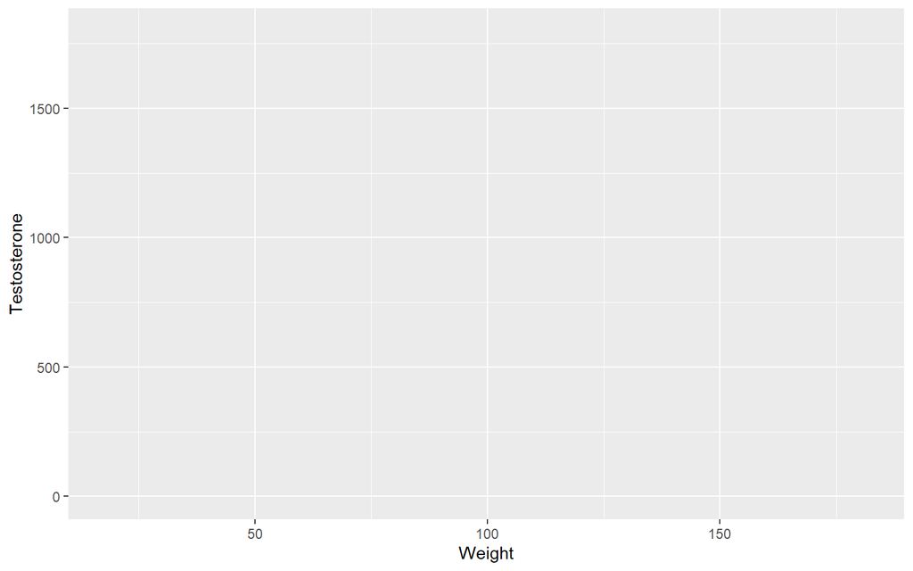

```r
nh_m <- nh %>% filter(Gender == "male" & !is.na(Testosterone)) %>% head(1500)

# The ggplot function creates an initial canvas
ggplot(data =  nh_m, aes(x = Weight, y = Testosterone))
```

When we do that we get a blank canvas with no data showing. That’s because all we’ve done is laid out a two-dimensional plot specifying what goes on the x and y axes, but we haven’t told it what kind of geometric object to plot. The obvious choice here is a point. Check out [docs.ggplot2.org](http://docs.ggplot2.org/) to see what kind of geoms are available.

Add `geom_point()`

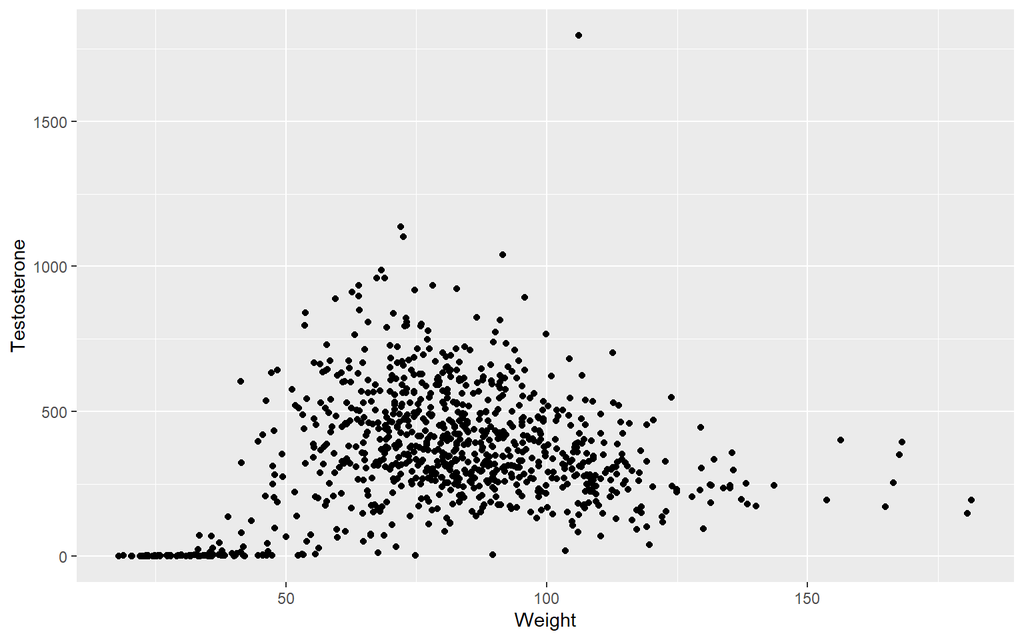

```r
ggplot(data =  nh_m, aes(x = Weight, y = Testosterone)) +
  geom_point()
```

Let’s add some color by changing all the points to be blue. By looking at the `geom_point` function in the help menu, you can see that their are several arguments/options that you can change within the geom. This is true for every geom that we will explore today and others that you might explore on your own.

The `colors()` function will provide you all of the colors that are initially available in R.

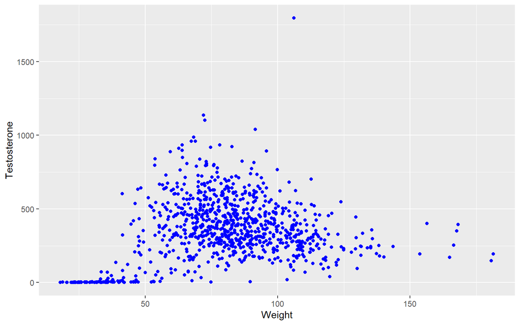

```r
# colors()
# Here the color = "blue" argument will make every point blue. This argument will behave differently depending on the type of geom you are using.
ggplot(data =  nh_m, aes(x = Weight, y = Testosterone)) +
  geom_point(color = "blue")
```

Instead of coloring by a static value, let’s color by Race (`Race1`). Remember that *any time* you want to map a variable onto the plot, it must be in a call to `aes()`

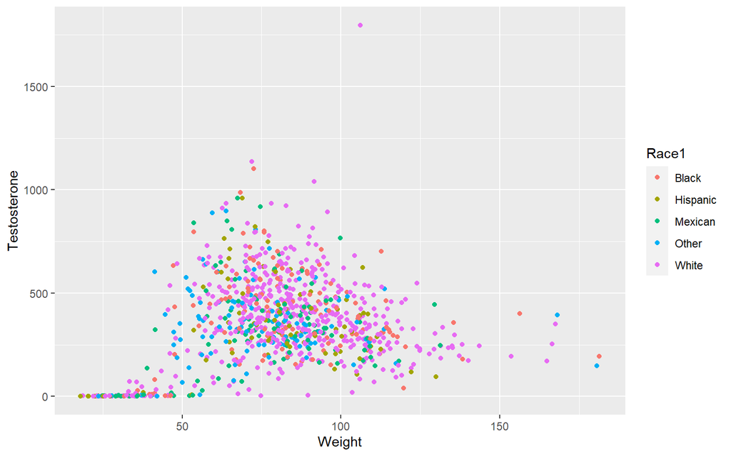

```r
# Notice that color is no longer a single value (ie: blue), but the value of a given category. This will now create a different color point for each value found in a category.
ggplot(data =  nh_m, aes(x = Weight, y = Testosterone)) +
  geom_point(aes(color = Race1))
```

Let’s add another layer showing a smoothed trend line. (and let’s go back to the normal geom_point shape). Remember, that each new layer will go on top of the previous one, meaning that the smoothed line will go on top of the points.

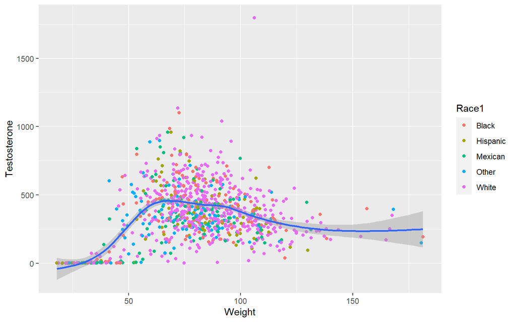

```r
# Use a + sign to connect together ggplot elements such as a geom.
ggplot(data =  nh_m, aes(x = Weight, y = Testosterone)) +
  geom_point(aes(color = Race1)) +
  geom_smooth()
```

Notice that `geom_smooth()` is fitting the trend line using a gam Model.

```r
# ?geom_smooth
```

Look at the Arguments section and read the bit about the method argument. We can specify a method, but if we allow the `method = "auto"` then it will fit loess for < 1000 data points and general additive models gam for >= 1000

Let’s change the method to be “lm” to fit a straight line using the `method` argument

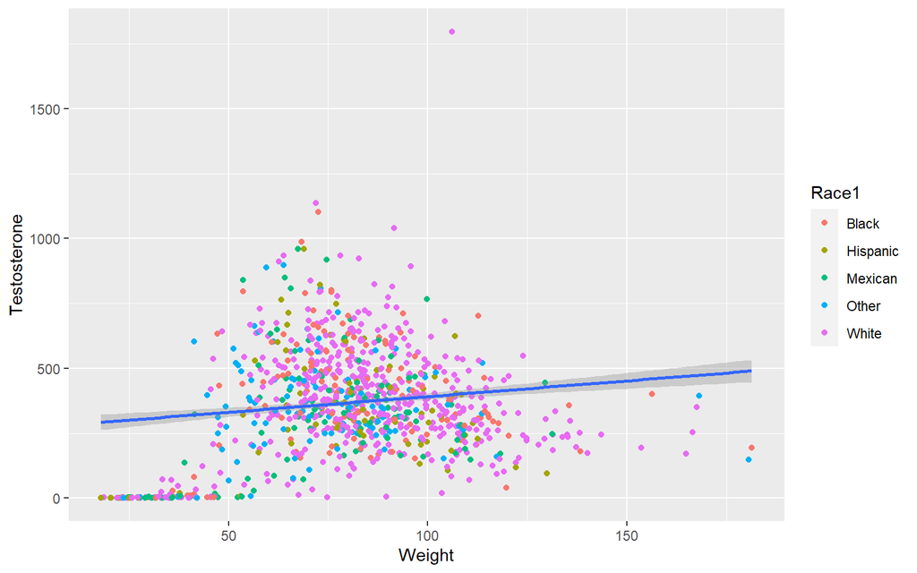

```r
ggplot(data =  nh_m, aes(x = Weight, y = Testosterone)) +
  geom_point(aes(color = Race1))+
  geom_smooth(method = "lm")
```

Let’s fit a smoothed line (allowing the default method = “auto”) separately for each Race

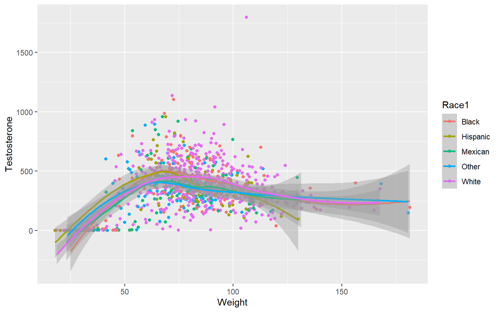

```r
# Notice that we have aesthetic mappings (aes) in both the point geom and the smooth geom.
ggplot(data =  nh_m, aes(x = Weight, y = Testosterone)) +
  geom_point(aes(color = Race1)) +
  geom_smooth(aes(color = Race1))
```

In the above code we now have three calls to `aes()`. One in the canvas layer, one in the `geom_point()` layer, and one in the `geom_smooth()` layer.

If we want ALL the layers to be colored by Race, we can just specify `color = Race1` in the top canvas layer and all the subsequent layers will inherit that aesthetic mapping just like they inherit the x and y from the canvas layer.

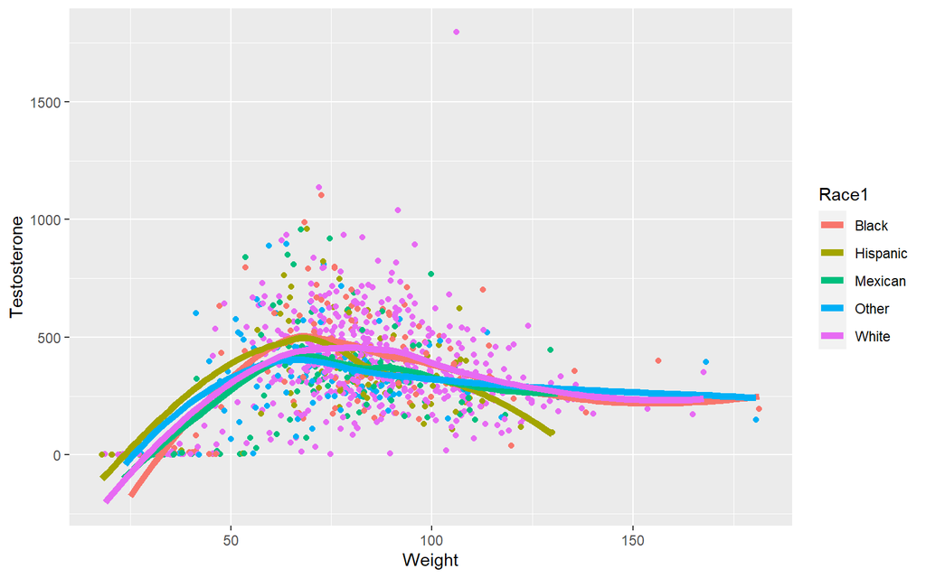

```r
# I've added lwd = 2 to the geom_smooth() function to create a thicker fitted line.
ggplot(data = nh_m, aes(x = Weight, y = Testosterone, color = Race1)) +
  geom_point() +
  geom_smooth(lwd = 2, se = FALSE)
```

```r
# se = FALSE removes standard error bars
```

### Facets

Facets display subsets of the data in different panels. There are a couple ways to do this, but `facet_wrap()` tries to sensibly wrap a series of facets into a 2-dimensional grid of small multiples.

The facet functions take a formula specifying which variables to facet by. If you have a look at the help for `?facet_wrap()` you’ll see that we can control how the wrapping is laid out.

Along the way to teaching you about faceting, I’ll show a strategy to build up a plot by saving layers you like to an object. This way, we can avoid having to copy-paste long lines of code.

Let’s start with a simple plot of `Weight` x and `Testosterone` on y.

Let’s create the canvas and then save that to object called `p`.

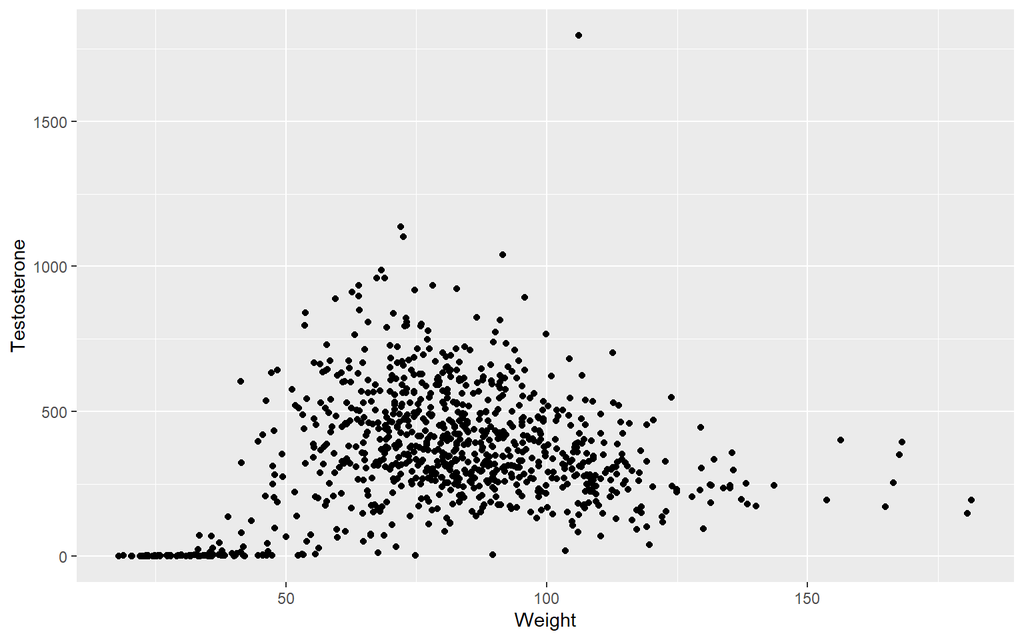

```r
p <- ggplot(nh_m, aes(x = Weight, y = Testosterone))
p + geom_point()
```

We’ll facet by `Race1` to show each Race in its own plot. Notice that we use the `~` in front of `Race1`. `facet_wrap` uses a formula as input, and the `~` is used when creating a formula.

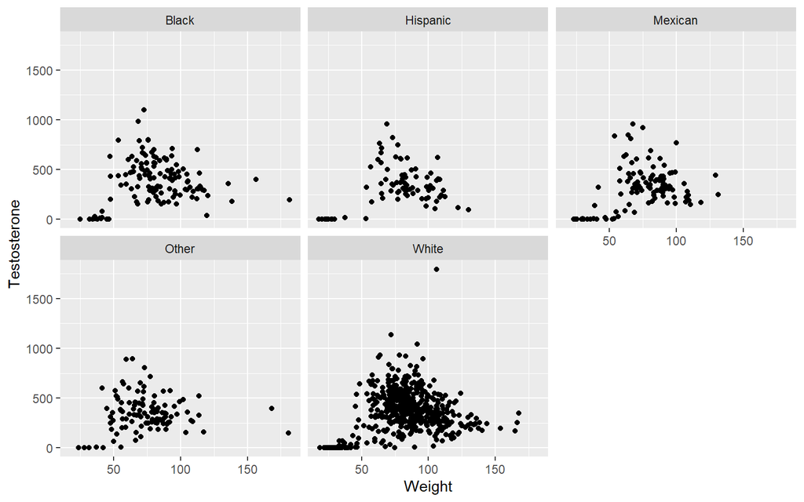

```r
# You could put another category in front of the ~ to create factorial graphs
p + geom_point() +
  facet_wrap(~Race1)
```

### Plotting univariate continuous data

What if we just wanted to visualize distribution of a single continuous variable? A histogram is the usual go-to visualization. Here we only have one aesthetic mapping instead of two.

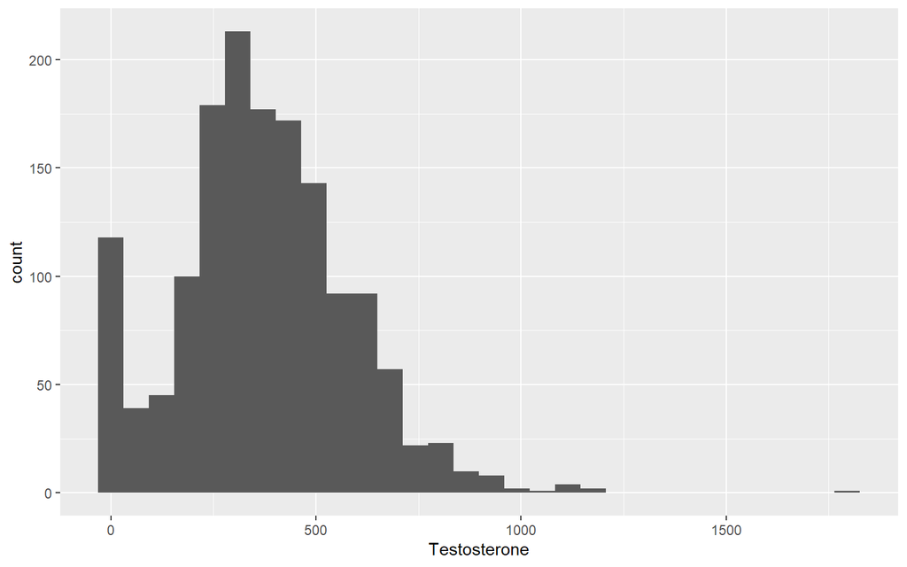

```r
# Let's investigate the distribution of the Testosterone variable
# set this as the canvas
p <- nh_m %>% ggplot(aes(Testosterone))
p + geom_histogram()
```

We change the number of bins that we have in our histograms. Generally, you want to do this utilizing prior knowledge or research.

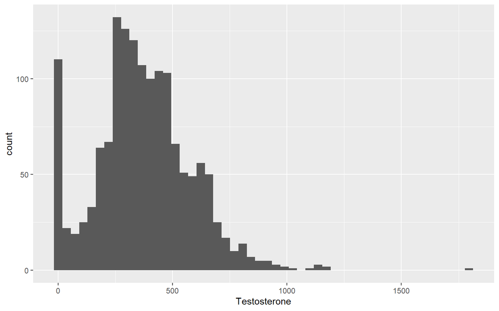

```r
# We can either use the bins option to specify the number of bins or you can use the bin.width option to specify the width of the bins.
p + geom_histogram(bins = 50)
```

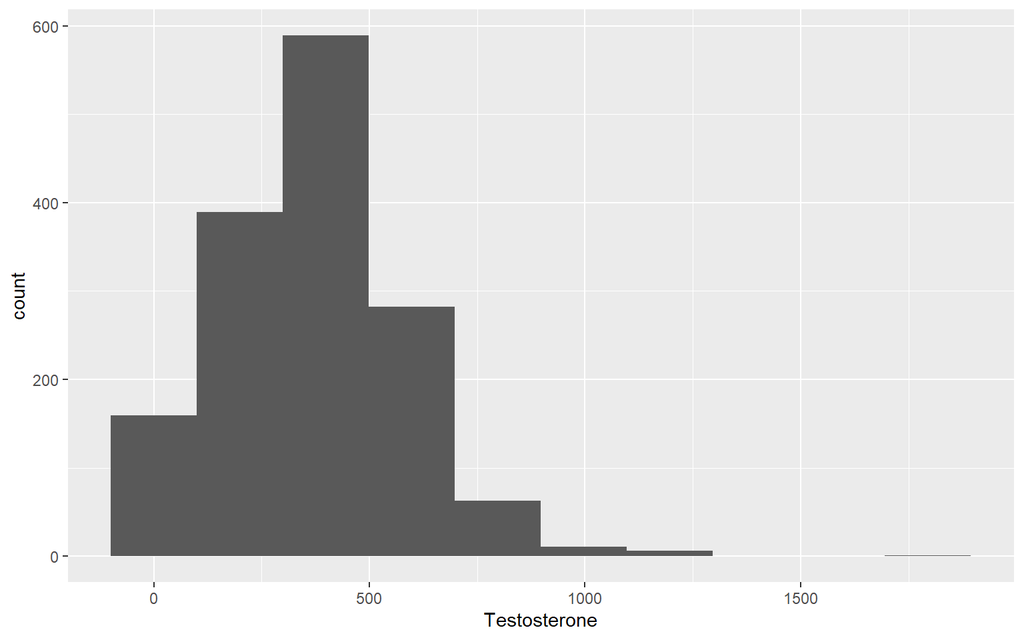

```r
p + geom_histogram(bins = 10)
```

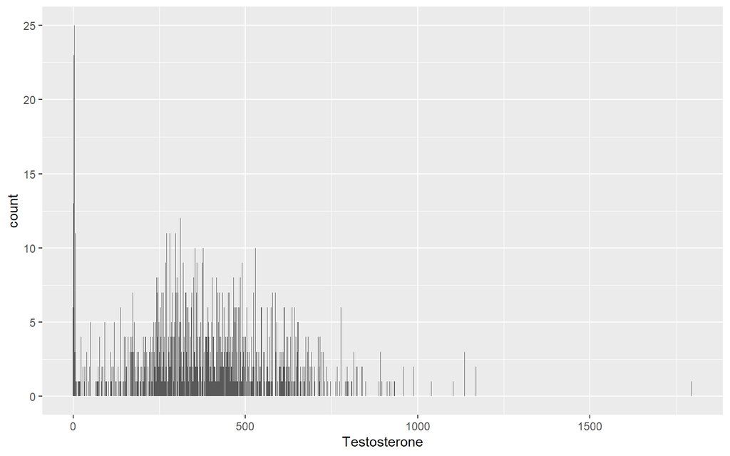

```r
p + geom_histogram(binwidth = 1)
```

We can also color the bars by our `Race1` variable.

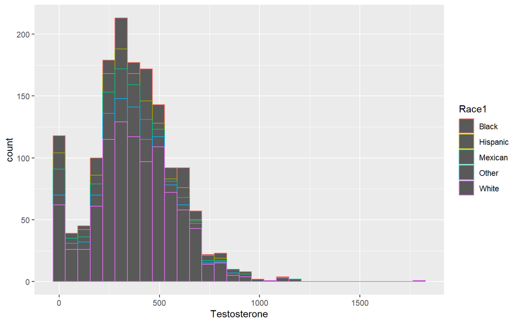

```r
p + geom_histogram(aes(color = Race1))
```

Well, that is not exactly what I meant. I wanted the inside of the bars colored. That argument is fill instead of color, just like with box plots.

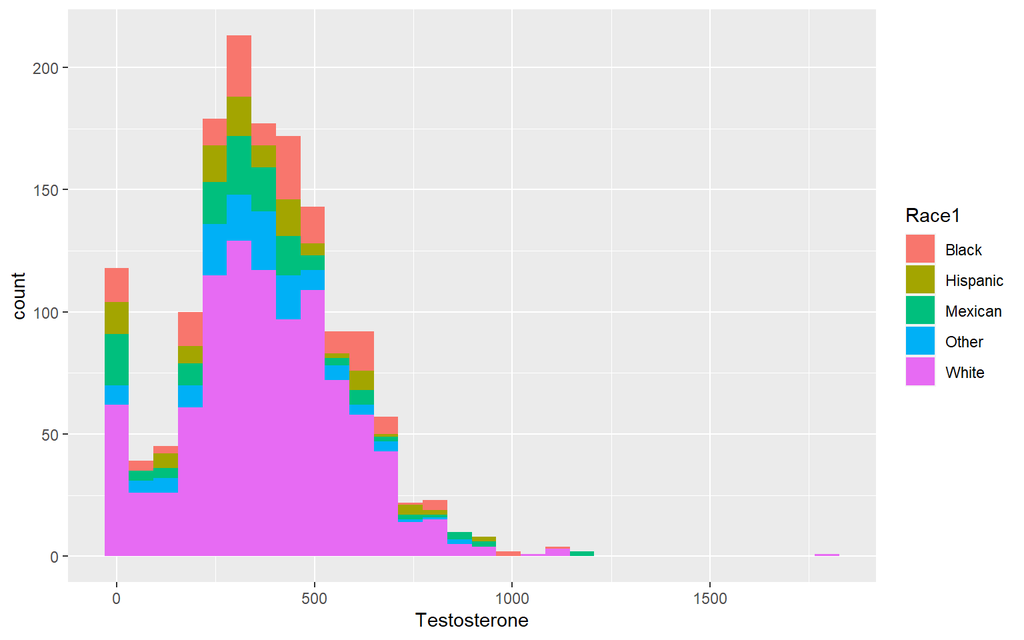

```r
p + geom_histogram(aes(fill = Race1))
```

If you look at the help for `?geom_histogram` you’ll see that by default it stacks overlapping data, so if two Races have the same Testosterone, one is plotted on the bottom and the second is plotted stacked on top of the first. This is a misleading visualization for that reason. Let’s change the position argument so that each Race has a baseline of 0.

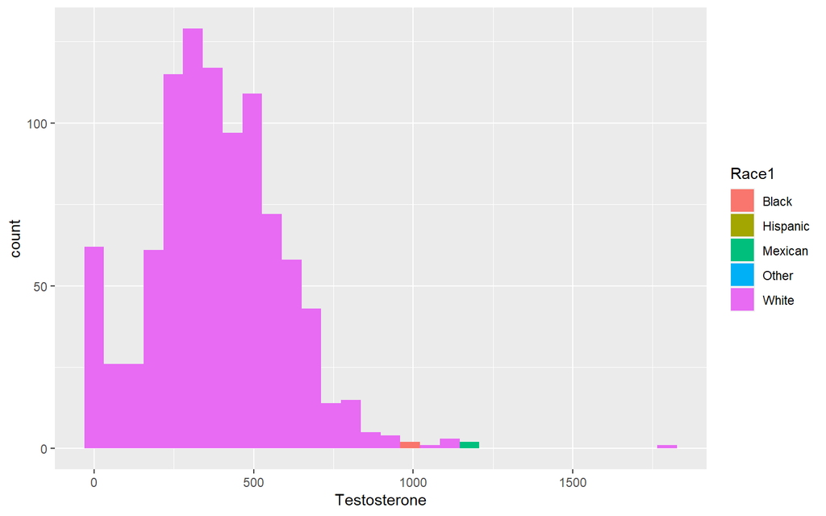

```r
# Here we use position = "identity"
p + geom_histogram(aes(fill = Race1), position = "identity")
```

That’s better, but still not great. Let’s use `alpha` to change the transparancy

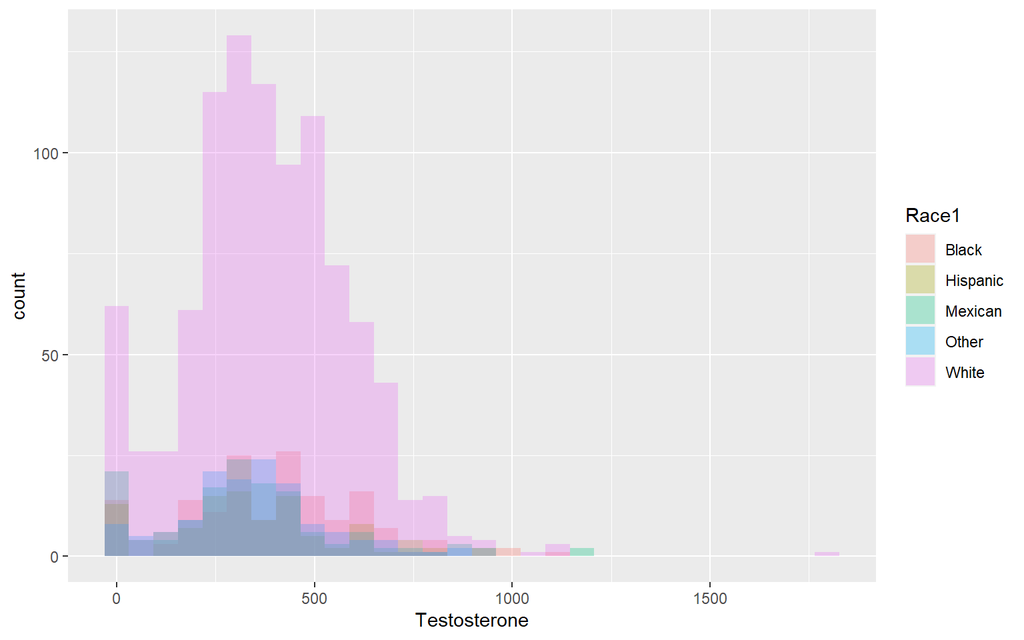

```r
p + geom_histogram(aes(fill = Race1), position = "identity", alpha = .3)
```

Maybe better, but let’s try faceting instead.

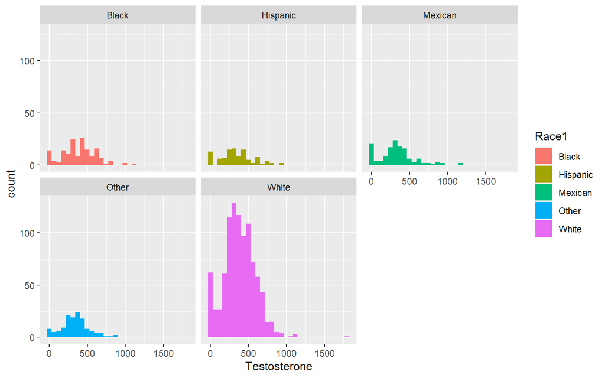

```r
p + geom_histogram(aes(fill = Race1), position = "identity") +
  facet_wrap(~Race1)
```

Great!

Let’s start back at p and plot a smoothed density curve instead of a histogram.

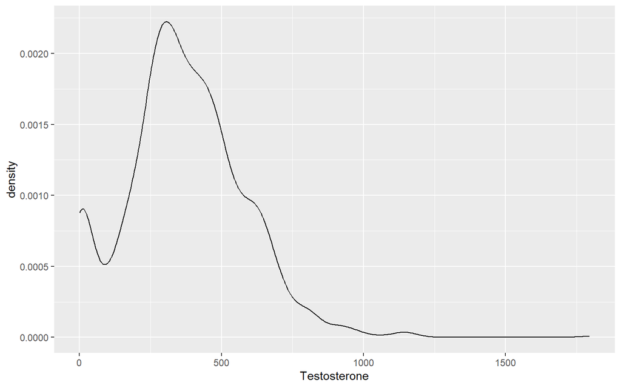

```r
p + geom_density()
```

Now color that by the `Race1`

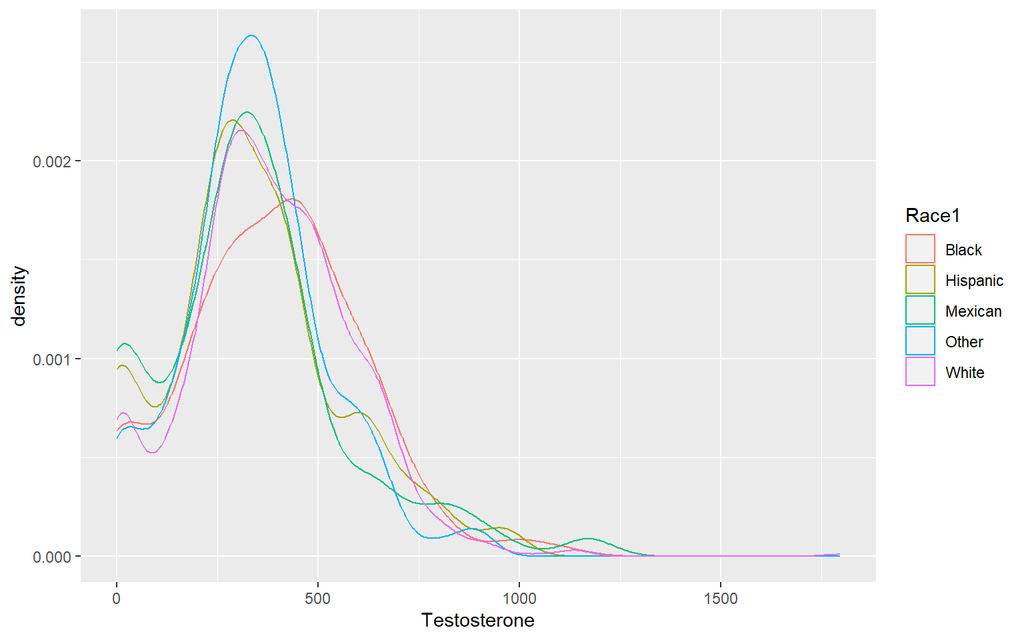

```r
p + geom_density(aes(color = Race1))
```

This could work for a couple of groups, but with 3 or more, it can get a bit busy. Let’s facet

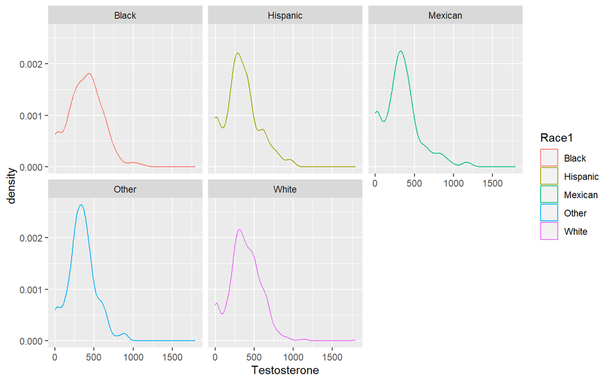

```r
p + geom_density(aes(color = Race1)) +
  facet_wrap(~Race1)
```

Change color to fill and you will see that instead of the outline being colored, the whole curve is filled

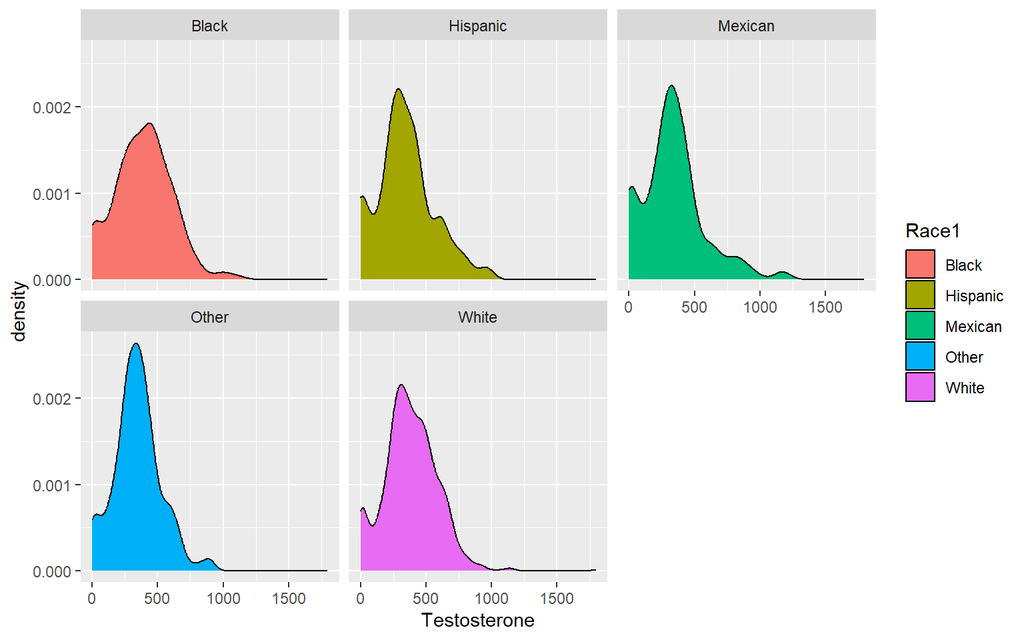

```r
p + geom_density(aes(fill = Race1)) +
  facet_wrap(~Race1)
```

### Saving plots

There are a few ways to save ggplots. The quickest way, that works in an interactive session, is to use the `ggsave()` function. You give it a file name and by default it saves the last plot that was printed to the screen.

```r
ggsave(file = "testost_race.png")
```

Where did it go? You will see that it went directly into your project folder. Typically, I would prefer to have a directory structure that has my code, images, results, etc. all separated out.

In a script, the best way to do it is to pass `ggsave()` the object containing the plot that is meant to be saved. We can also adjust things like the width, height, and resolution. `ggsave()` also recognizes the name of the file extension and saves the appropriate kind of file. Let’s save a PDF.

```r
# I am first going to create a single column of graphs so that each graph in the facet wrap gets its own row
pfinal <- p +
  geom_density(aes(fill = Race1)) +
  facet_wrap(~Race1, ncol = 1)
pfinal
ggsave(pfinal, file = "test_race.pdf", width = 7, height = 12)
```

[output not shown]

### Publication ready graphics

Let’s keep using our density plot and add some useful aesthetic elements.

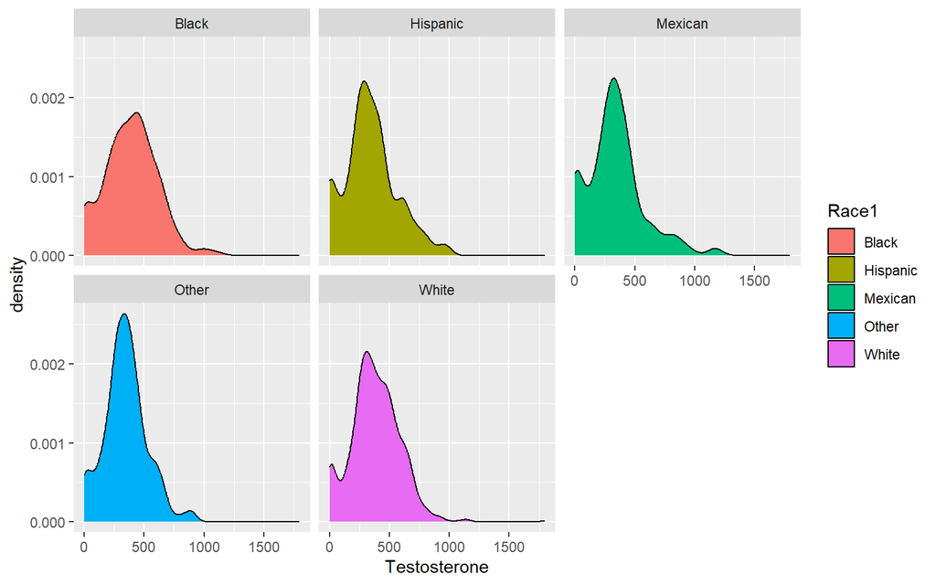

```r
# create the canvas
# add the layers and save them onto p
p <- nh_m %>% ggplot(aes(Testosterone)) +
  geom_density(aes(fill = Race1)) +
  facet_wrap(~Race1)

p
```

Let’s add proper axes labels using labs(). Keep adding to create a title, subtitle, and better legend title (color).

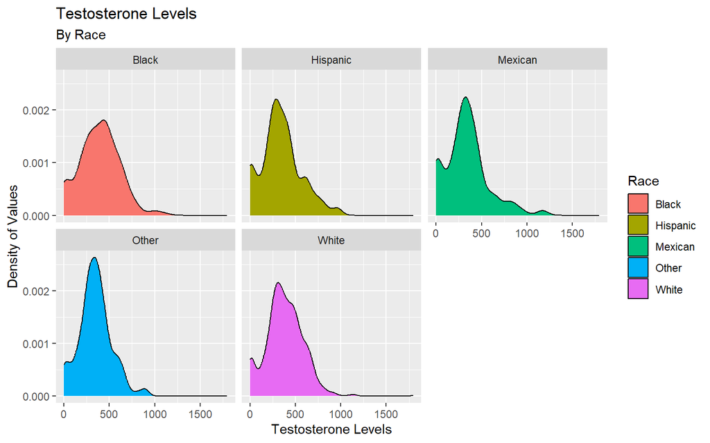

```r
# save the labs onto p
p <- p + labs(x = "Testosterone Levels",
         y = "Density of Values",
         title = "Testosterone Levels",
         subtitle = "By Race",
         fill = "Race")
p
```

The author of ggplot2, Hadley Wickham has chosen the “gray” theme as the default, but there are others that automatically make some aesthetic choices for you.

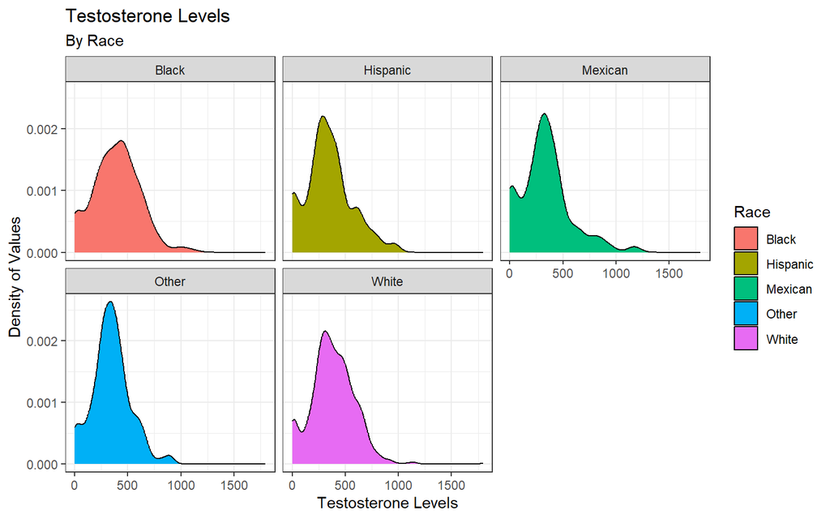

```r
p + theme_bw()
```

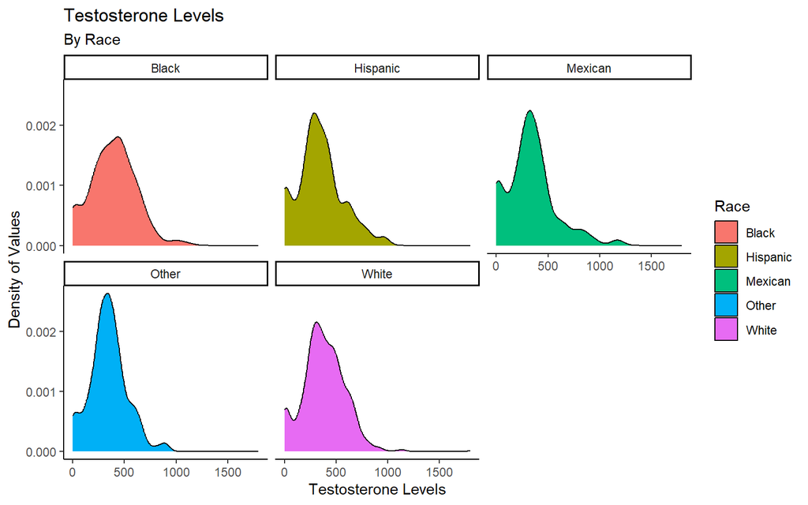

```r
p + theme_classic()
```

### Creating your own themes

If you wanted to, you can also customize your own plots using the `theme` function. Within this function there are thousands of combinations that you can choose to aesthetically change your graphs, ranging from the color of your titles to the shape of the outline of the legend. I tend to use the a built-in theme, generally `theme_classic` and then make a few additions from there. I will only give a small example of how to do this, but to cover all of the things you could do in this function would take days/weeks.

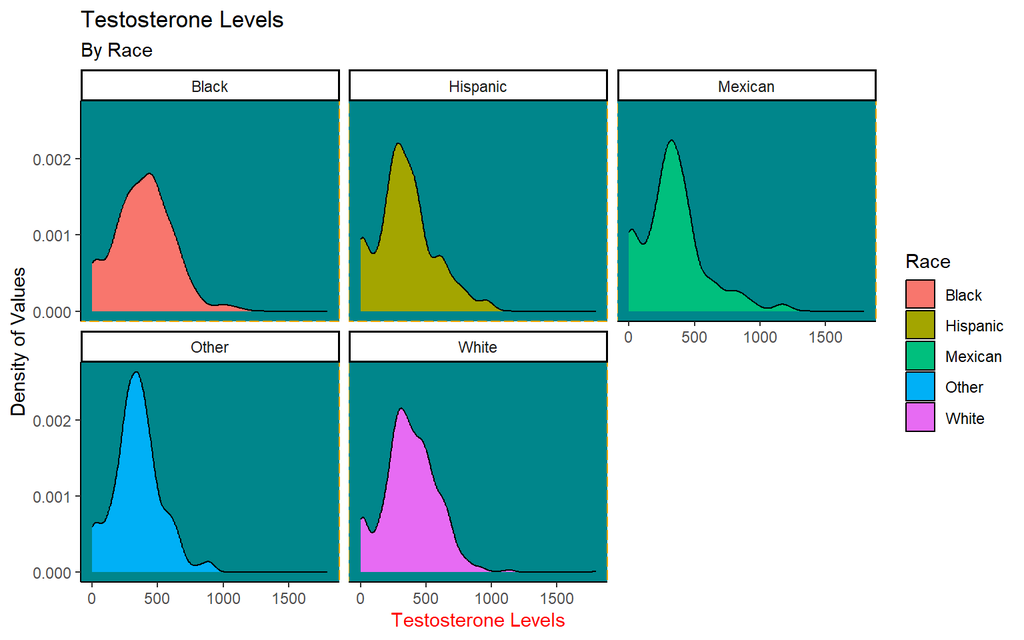

```r
#?theme
mytheme <- theme(axis.title.x = element_text(color = "red"),
                 panel.background = element_rect(color = "orange",
                                                 fill = "turquoise4",
                                                 linetype = "longdash")
                )

p + theme_classic() + mytheme
```

Sometimes you may want to go outside of the colors that ggplot provides for you when filling in histograms, coloring points, etc. Fortunately, plenty of tools are provided to customize these color sets.

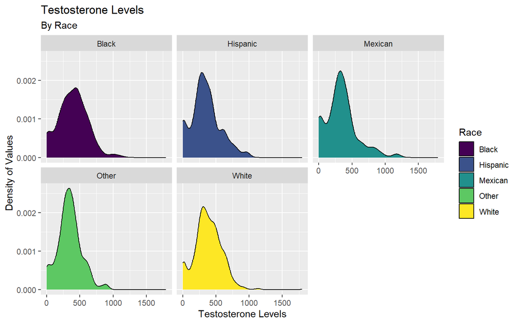

```r
#colors()
p + scale_fill_viridis_d()
```

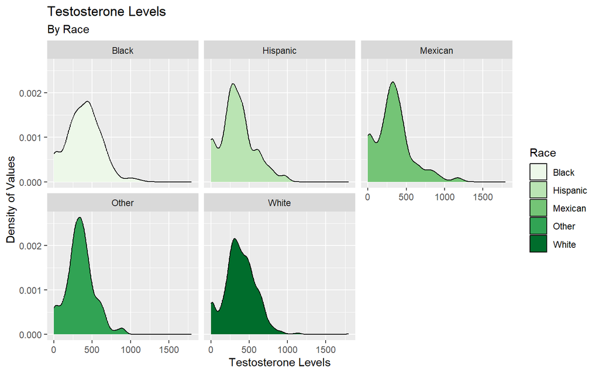

```r
p + scale_fill_brewer(palette = "Greens")
```

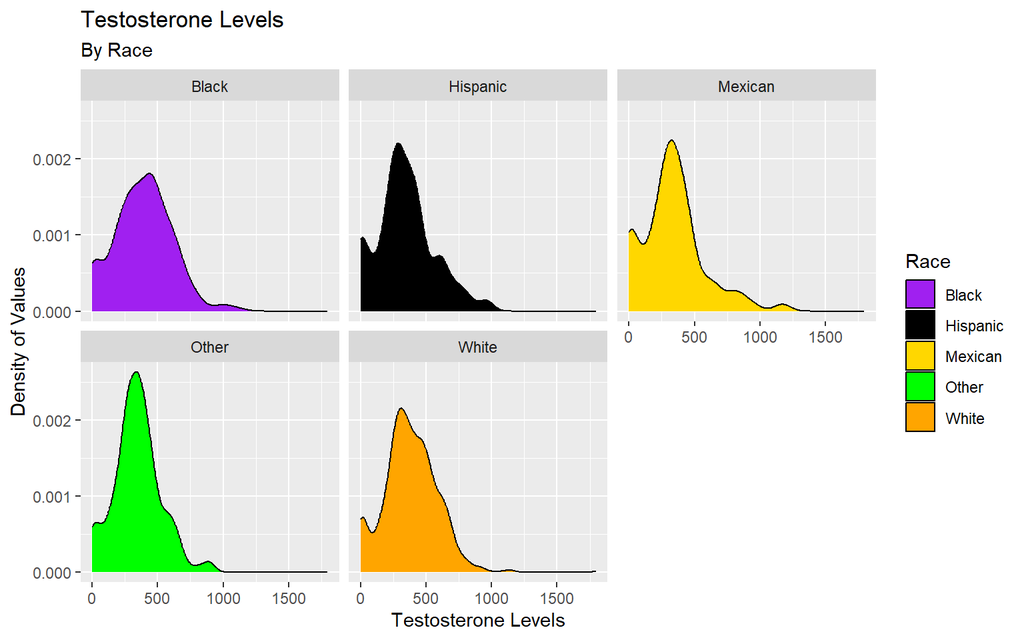

```r
p + scale_fill_manual(values = c("purple", "black", "gold", "green", "orange"))
```

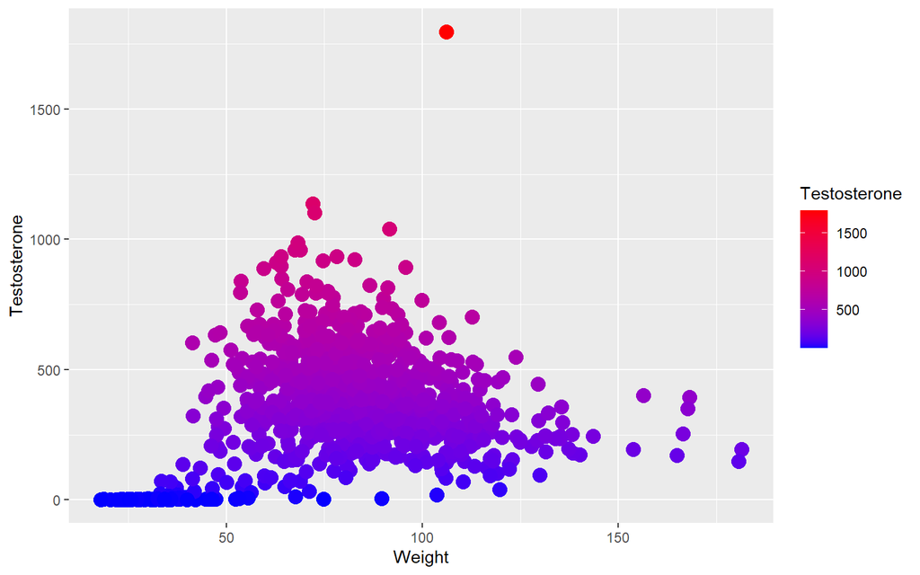

```r
nh_m %>% ggplot(aes(Weight, Testosterone, color = Testosterone)) +
  geom_point(size = 4) +
  scale_color_gradient(low  = "blue", high = "red")
```